# Repeat CRC paper’s Figure 4C

Sehyun Oh

2020-11-01

# 1 Setup

- CRC paper actually used both training and validation datasets (total of 18) for Figure 4. `Fig4C_CMSvs.R` and `Fig4C_contScores.R` scripts are using only 10 validation datasets. If you want to use all 18 datasets, block the line 11-13 of those scripts.

```r
## line 11-13
# load("data/eSets/trainingSetNames.RData")
# validationSetNames <- setdiff(setNames, trainingSetNames)
# setNames <- validationSetNames
```

- Fig4C_CMSvs.R script requires three environmental variables set before running: `m2_name` (column name for the model to be compared to CMS), `m2_1` and `m2_2` (names of the two model variables that form the group to be compared to CMS)
- Fig4C_contScores.R script requires six environmental variables set before running: `m1_name`, `m1_1`, `m1_2` for one model, `m2_name`, `m2_1`, `m2_2` for the other.

# 2 Compare to CMS

## 2.1 CMS vs. PCSS1/2

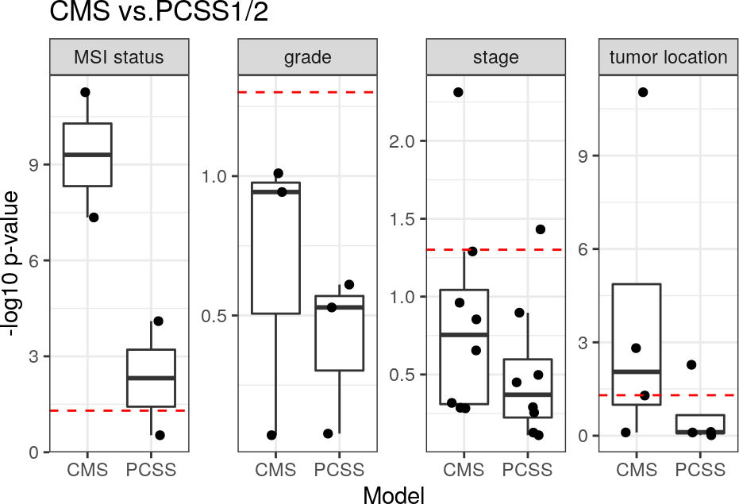

```r
m2_name <- "PCSS"
m2_1 <- "PCSS1"
m2_2 <- "PCSS2"
source("R/Fig4C_CMSvs.R", print.eval = TRUE)
## Warning: Removed 46 rows containing non-finite values (stat_boxplot).
## Warning: Removed 46 rows containing missing values (geom_point).
```

## 2.2 CMS vs. RAV1575/834

RAV1575/834 are the most similar PCclsuters to PCSS1/2, respectively, based on Pearson correlation.

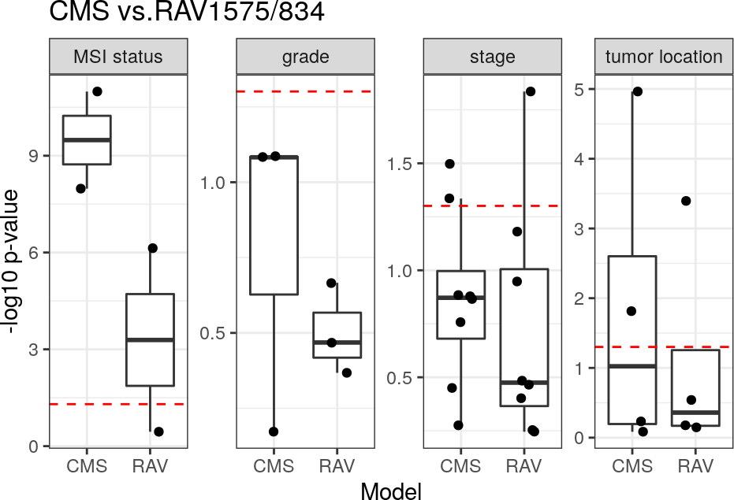

```r
m2_name <- "RAV"
m2_1 <- "RAV1575"
m2_2 <- "RAV834"
source("R/Fig4C_CMSvs.R", print.eval = TRUE)
## Warning: Removed 46 rows containing non-finite values (stat_boxplot).
## Warning: Removed 46 rows containing missing values (geom_point).
```

## 2.3 CMS vs. RAV834/833

RAV834/833 have the largest r-squared score when we compared the samples scores against the metadata, CMS.

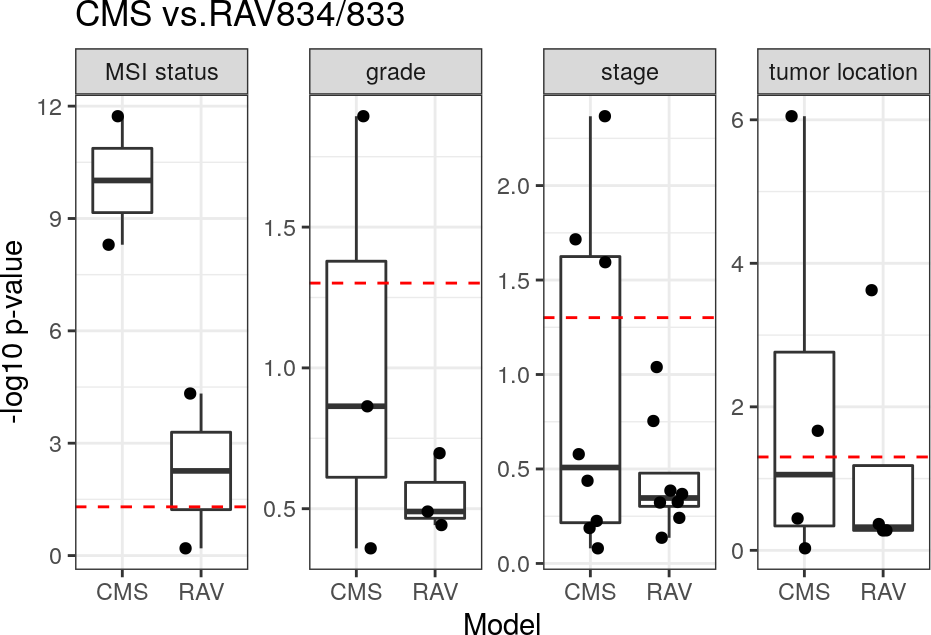

[output not shown]

```r
m2_name <- "RAV"
m2_1 <- "RAV834"
m2_2 <- "RAV833"
source("R/Fig4C_CMSvs.R", print.eval = TRUE)
## Warning: Removed 46 rows containing non-finite values (stat_boxplot).
## Warning: Removed 46 rows containing missing values (geom_point).
```

# 3 Compare continuous scores

## 3.1 PCSS vs. RAV1575/834

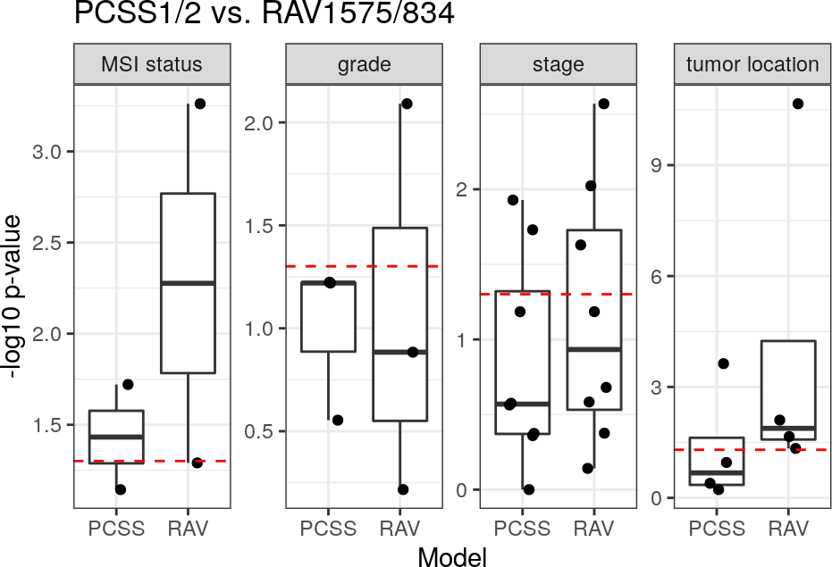

```r
m1_name <- "PCSS"
m1_1 <- "PCSS1"
m1_2 <- "PCSS2"
m2_name <- "RAV"
m2_1 <- "RAV1575"
m2_2 <- "RAV834"

source("R/Fig4C_contScores.R", print.eval = TRUE)
## Warning: Removed 46 rows containing non-finite values (stat_boxplot).
## Warning: Removed 46 rows containing missing values (geom_point).
```

## 3.2 PCSS vs. RAV834/833

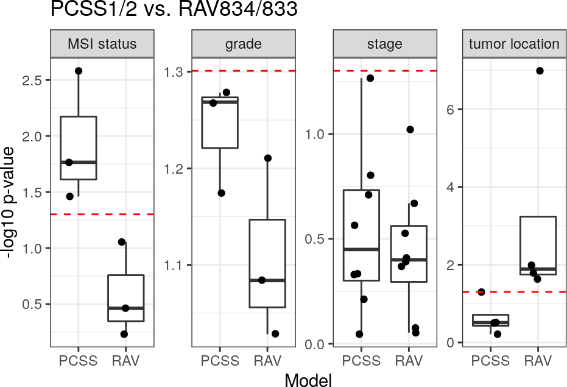

[output not shown]

```r
m1_name <- "PCSS"
m1_1 <- "PCSS1"
m1_2 <- "PCSS2"
m2_name <- "RAV"
m2_1 <- "RAV834"
m2_2 <- "RAV833"

source("R/Fig4C_contScores.R", print.eval = TRUE)
## Warning: Removed 44 rows containing non-finite values (stat_boxplot).
## Warning: Removed 44 rows containing missing values (geom_point).
```

## 3.3 PCSS vs. RAV834/3290

RAV3290 is associated with “stage” metadata of CRC datasets.

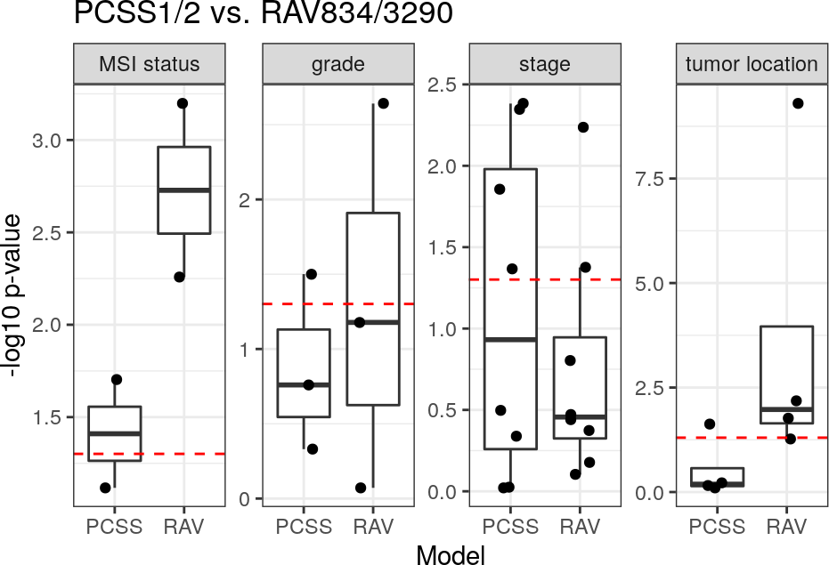

```r
m1_name <- "PCSS"
m1_1 <- "PCSS1"
m1_2 <- "PCSS2"
m2_name <- "RAV"
m2_1 <- "RAV834"
m2_2 <- "RAV3290"

source("R/Fig4C_contScores.R", print.eval = TRUE)
## Warning: Removed 46 rows containing non-finite values (stat_boxplot).
## Warning: Removed 46 rows containing missing values (geom_point).
```

## 3.4 PCSS vs. RAV834/596

RAV596 is associated with “grade” metadata of CRC datasets.

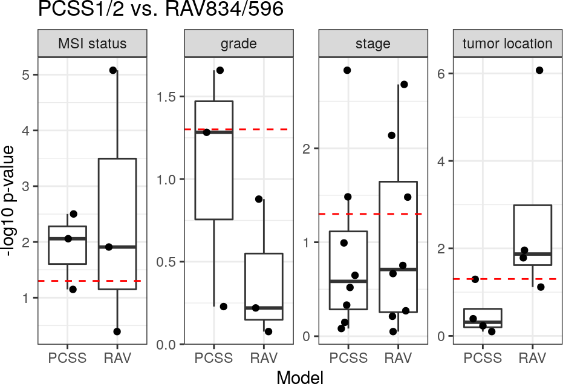

```r
m1_name <- "PCSS"
m1_1 <- "PCSS1"
m1_2 <- "PCSS2"
m2_name <- "RAV"
m2_1 <- "RAV834"
m2_2 <- "RAV596"

source("R/Fig4C_contScores.R", print.eval = TRUE)
## Warning: Removed 44 rows containing non-finite values (stat_boxplot).
## Warning: Removed 44 rows containing missing values (geom_point).
```

# 4 Session Info

```r
sessionInfo()
## R version 4.0.3 (2020-10-10)
## Platform: x86_64-pc-linux-gnu (64-bit)
## Running under: Ubuntu 18.04.5 LTS
##
## Matrix products: default
## BLAS:   /usr/lib/x86_64-linux-gnu/openblas/libblas.so.3
## LAPACK: /usr/lib/x86_64-linux-gnu/libopenblasp-r0.2.20.so
##
## locale:
##  [1] LC_CTYPE=en_US.UTF-8       LC_NUMERIC=C
##  [3] LC_TIME=en_US.UTF-8        LC_COLLATE=en_US.UTF-8
##  [5] LC_MONETARY=en_US.UTF-8    LC_MESSAGES=en_US.UTF-8
##  [7] LC_PAPER=en_US.UTF-8       LC_NAME=C
##  [9] LC_ADDRESS=C               LC_TELEPHONE=C
## [11] LC_MEASUREMENT=en_US.UTF-8 LC_IDENTIFICATION=C
##
## attached base packages:
## [1] parallel  stats     graphics  grDevices utils     datasets  methods
## [8] base
##
## other attached packages:
##  [1] logistf_1.24        metafor_2.4-0       Matrix_1.2-18
##  [4] survival_3.2-7      forcats_0.5.0       stringr_1.4.0
##  [7] dplyr_1.0.2         purrr_0.3.4         readr_1.4.0
## [10] tidyr_1.1.2         tibble_3.0.4        ggplot2_3.3.2
## [13] tidyverse_1.3.0     Biobase_2.49.1      BiocGenerics_0.35.4
## [16] BiocStyle_2.17.2
##
## loaded via a namespace (and not attached):
##  [1] Rcpp_1.0.5           lubridate_1.7.9      lattice_0.20-41
##  [4] formula.tools_1.7.1  assertthat_0.2.1     digest_0.6.27
##  [7] R6_2.4.1             cellranger_1.1.0     backports_1.1.10
## [10] reprex_0.3.0         evaluate_0.14        httr_1.4.2
## [13] pillar_1.4.6         rlang_0.4.8          readxl_1.3.1
## [16] rstudioapi_0.11      blob_1.2.1           magick_2.5.0
## [19] rmarkdown_2.5        labeling_0.4.2       splines_4.0.3
## [22] munsell_0.5.0        broom_0.7.2          compiler_4.0.3
## [25] modelr_0.1.8         xfun_0.18            pkgconfig_2.0.3
## [28] mgcv_1.8-33          htmltools_0.5.0      tidyselect_1.1.0
## [31] bookdown_0.21        fansi_0.4.1          crayon_1.3.4
## [34] dbplyr_1.4.4         withr_2.3.0          grid_4.0.3
## [37] nlme_3.1-149         jsonlite_1.7.1       gtable_0.3.0
## [40] lifecycle_0.2.0      DBI_1.1.0            magrittr_1.5
## [43] scales_1.1.1         cli_2.1.0            stringi_1.5.3
## [46] farver_2.0.3         fs_1.5.0             mice_3.11.0
## [49] xml2_1.3.2           ellipsis_0.3.1       generics_0.0.2
## [52] vctrs_0.3.4          tools_4.0.3          glue_1.4.2
## [55] hms_0.5.3            yaml_2.2.1           colorspace_1.4-1
## [58] BiocManager_1.30.10  operator.tools_1.6.3 rvest_0.3.6
## [61] knitr_1.30           haven_2.3.1
```